# Longley data example

Michael Friendly

2024-11-29

## Load packages

```r
library(genridge)
library(car)     # for vif() generic
```

## Load the data

```r
data(longley, package="datasets")
str(longley)
```

```
## 'data.frame':    16 obs. of  7 variables:
##  $ GNP.deflator: num  83 88.5 88.2 89.5 96.2 ...
##  $ GNP         : num  234 259 258 285 329 ...
##  $ Unemployed  : num  236 232 368 335 210 ...
##  $ Armed.Forces: num  159 146 162 165 310 ...
##  $ Population  : num  108 109 110 111 112 ...
##  $ Year        : int  1947 1948 1949 1950 1951 1952 1953 1954 1955 1956 ...
##  $ Employed    : num  60.3 61.1 60.2 61.2 63.2 ...
```

## Fit the model predicting `Employed` & examine VIFs

```r
longley.lm <- lm(Employed ~ GNP + Unemployed + Armed.Forces +
                   Population + Year + GNP.deflator,
                 data=longley)
vif(longley.lm)
```

```
##          GNP   Unemployed Armed.Forces   Population         Year GNP.deflator
##     1788.513       33.619        3.589      399.151      758.981      135.532
```

## Get ridge regression estimates

The ridge shrinkage factors are specified by `lambda` (aka “k”)

```r
lambda <- c(0, 0.002, 0.005, 0.01, 0.02, 0.04, 0.08)
lridge <- ridge(Employed ~ GNP + Unemployed + Armed.Forces +
                  Population + Year + GNP.deflator,
                data=longley, lambda=lambda)
print(lridge, digits = 2)
```

```
## Ridge Coefficients:
##        GNP     Unemployed  Armed.Forces  Population  Year    GNP.deflator
## 0.000  -3.447  -1.828      -0.696        -0.344       8.432   0.157
## 0.002  -2.114  -1.644      -0.658        -0.713       7.466   0.022
## 0.005  -1.042  -1.491      -0.623        -0.936       6.567  -0.042
## 0.010  -0.180  -1.361      -0.588        -1.003       5.656  -0.026
## 0.020   0.499  -1.245      -0.548        -0.868       4.626   0.098
## 0.040   0.906  -1.155      -0.504        -0.523       3.577   0.321
## 0.080   1.091  -1.086      -0.458        -0.086       2.642   0.570
```

## The `"ridge"` object

The main thing is the coefficients, (returned by `coef()`) but the `ridge` object contains info used by other functions so it doesn’t have to be computed again.

```r
names(lridge)
```

```
##  [1] "lambda"   "df"       "coef"     "cov"      "mse"      "scales"
##  [7] "kHKB"     "kLW"      "GCV"      "kGCV"     "criteria" "svd.D"
## [13] "svd.U"    "svd.V"
```

## Standard, univariate trace plot

`traceplot()` plots estimated coefficients against the ridge constant, λ

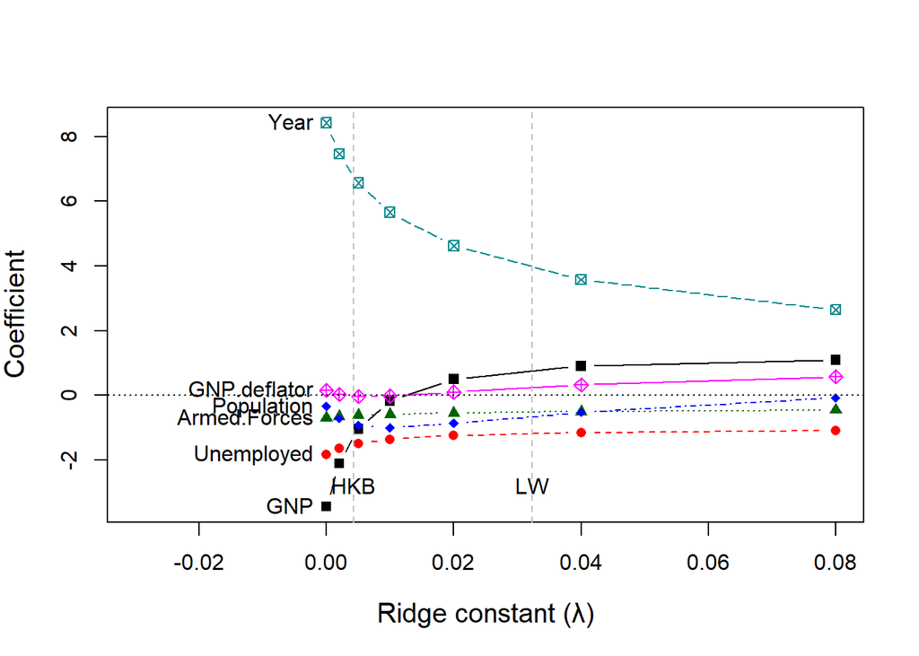

```r
traceplot(lridge,
          X = "lambda",
          xlab = "Ridge constant (λ)",
          xlim = c(-0.02, 0.08),
          cex.lab=1.25)
```

## Better: plot against effective degrees of freedom

Shrinkage can be better understood in terms of the equivalent number of degrees of freedom. Note that these values are more nearly linearly spaced.

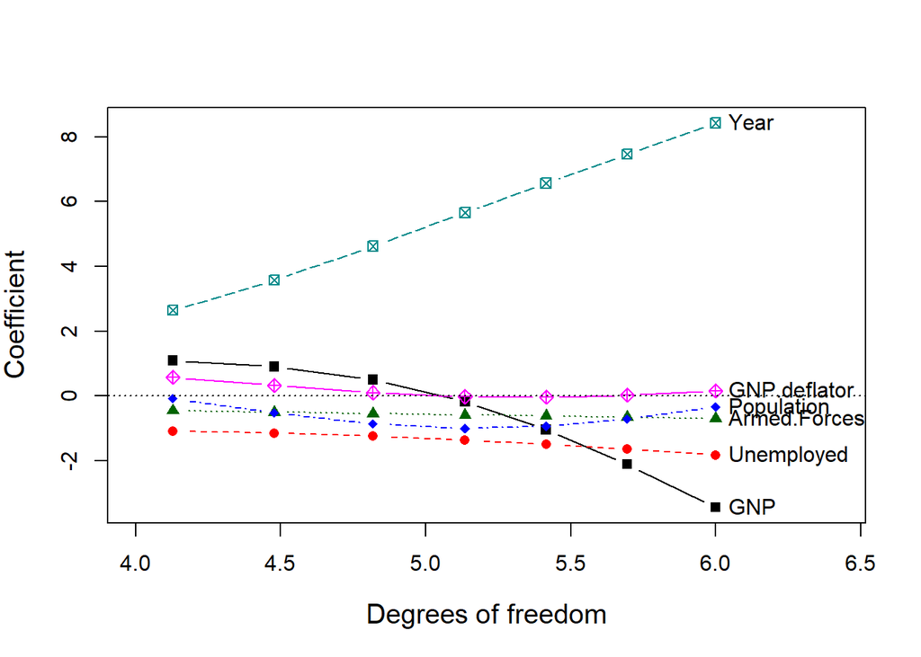

```r
traceplot(lridge,
          X = "df",
          xlim = c(4, 6.2), cex.lab=1.25)
```

## Even BETTER: Bivariate ridge trace plot

Shows bias *and* precision by confidence ellipses for the coefficients

```r
clr <-  c("black", "red", "brown", "darkgreen","blue", "cyan4", "magenta")
pch <- c(15:18, 7, 9, 12)
lambdaf <- c(expression(~widehat(beta)^OLS), as.character(lambda[-1]))
```

Plot GNP vs. Unemployed

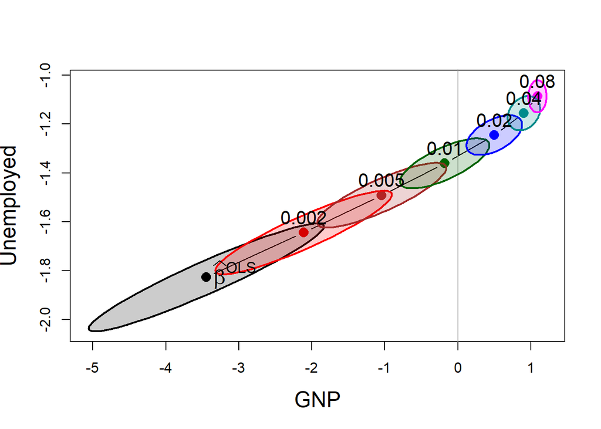

```r
plot(lridge, variables=c(1,2),
     radius=0.5, cex.lab=1.5, col=clr,
     labels=NULL, fill=TRUE, fill.alpha=0.2)
text(lridge$coef[1,1], lridge$coef[1,2],
     expression(~widehat(beta)^OLS), cex=1.5, pos=4, offset=.1)
text(lridge$coef[-1,c(1,2)], lambdaf[-1], pos=3, cex=1.3)
```

Plot GNP vs. Population

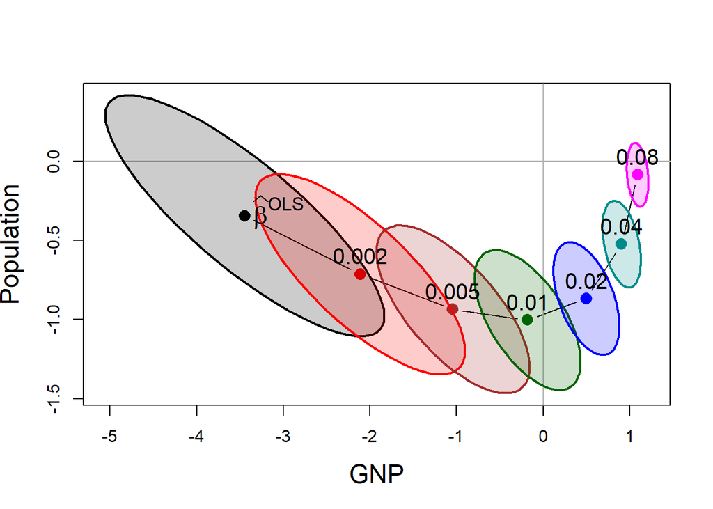

```r
plot(lridge, variables=c(1,4),
     radius=0.5, cex.lab=1.5, col=clr,
     labels=NULL, fill=TRUE, fill.alpha=0.2)
text(lridge$coef[1,1], lridge$coef[1,4],
     expression(~widehat(beta)^OLS), cex=1.5, pos=4, offset=.1)
text(lridge$coef[-1,c(1,4)], lambdaf[-1], pos=3, cex=1.3)
```

## Scatterplot matrix

See all bivariate pairwise views of effects of shrinkage. Some of the paths are monotonic, while others are not.

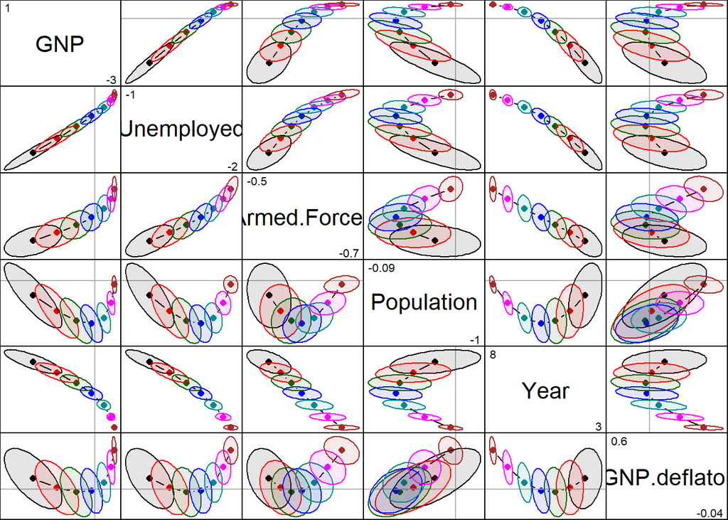

```r
pairs(lridge, radius=0.5, diag.cex = 2,
      fill = TRUE, fill.alpha = 0.1)
```

## Visualizing the bias-variance tradeoff

The function `precision()` calculates a number of measures of the effect of shrinkage of the coefficients in relation to the “size” of the covariance matrix.

```r
pridge <- precision(lridge) |> print(digits = 3)
```

```
##       lambda   df   det  trace max.eig norm.beta
## 0.000  0.000 6.00 -12.9 18.119  15.419     1.000
## 0.002  0.002 5.70 -13.6 11.179   8.693     0.857
## 0.005  0.005 5.42 -14.4  6.821   4.606     0.741
## 0.010  0.010 5.14 -15.4  4.042   2.181     0.637
## 0.020  0.020 4.82 -16.8  2.218   1.025     0.528
## 0.040  0.040 4.48 -18.7  1.165   0.581     0.423
## 0.080  0.080 4.13 -21.1  0.587   0.260     0.337
```

## Plot method for `"precision"` objects

`genridge` recently gained a `plot()` method to plot a measures of shrinkage (“bias”) against a measure of variance of the covariance matrices (inverse “precision”)

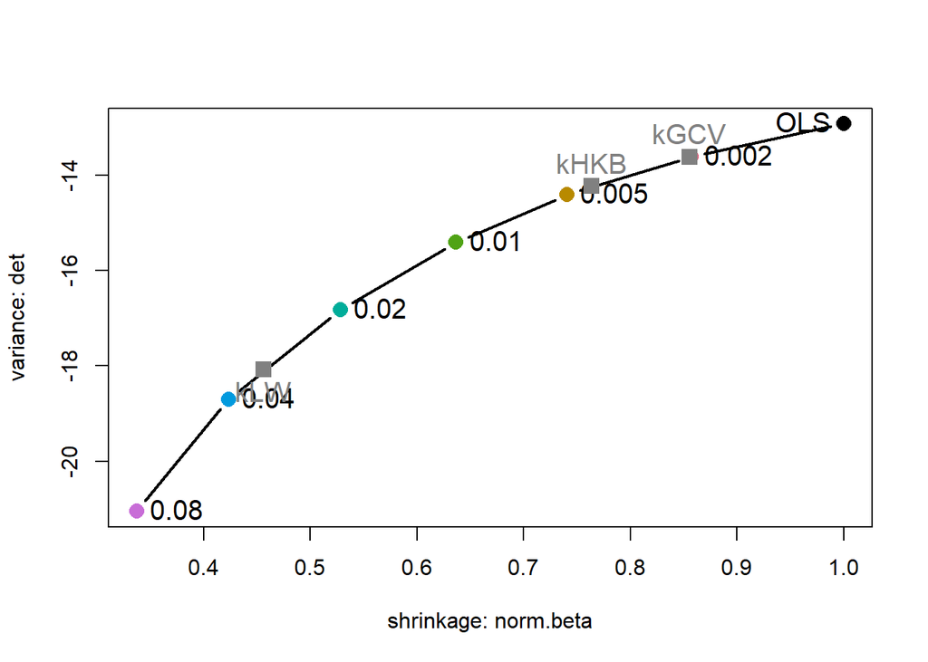

```r
plot(pridge, criteria = lridge$criteria)
```

Label the points with `df` and compare `"det"` = log |Var(β)| vs. `"trace"` = tr(Var(β)). These have quite different trajectories.

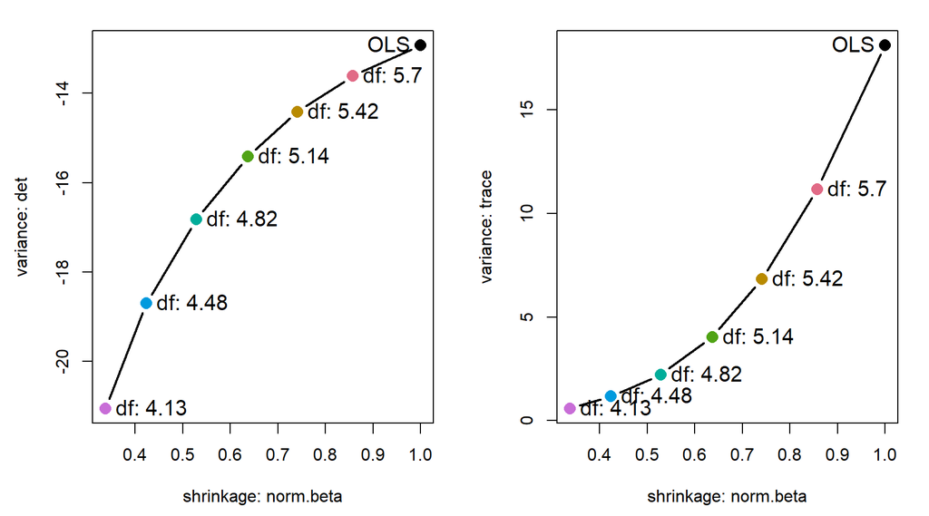

```r
op <- par(mar = c(4,4,1,1)+ .5, mfrow = c(1,2))
plot(pridge,
     labels = "df", label.prefix="df:")

plot(pridge, yvar="trace",
     labels = "df", label.prefix="df:")
par(op)
```

## Low-rank views

The `pca` method transforms a `"ridge"` object from parameter space to PCA space defined by the SVD of X. It returns an object of class `"pcaridge"`. Note there is very little shrinkage in the first 4 dimensions.

```r
plridge <- pca(lridge) |> print(digits = 3)
```

```
## Ridge Coefficients:
##        dim1   dim2   dim3   dim4   dim5   dim6
## 0.000  1.515  0.379  1.801  0.346  5.974  6.742
## 0.002  1.515  0.379  1.800  0.343  5.695  5.062
## 0.005  1.515  0.379  1.799  0.339  5.322  3.685
## 0.010  1.515  0.379  1.796  0.332  4.799  2.536
## 0.020  1.515  0.379  1.790  0.319  4.010  1.561
## 0.040  1.515  0.379  1.779  0.296  3.018  0.883
## 0.080  1.514  0.378  1.758  0.259  2.019  0.472
```

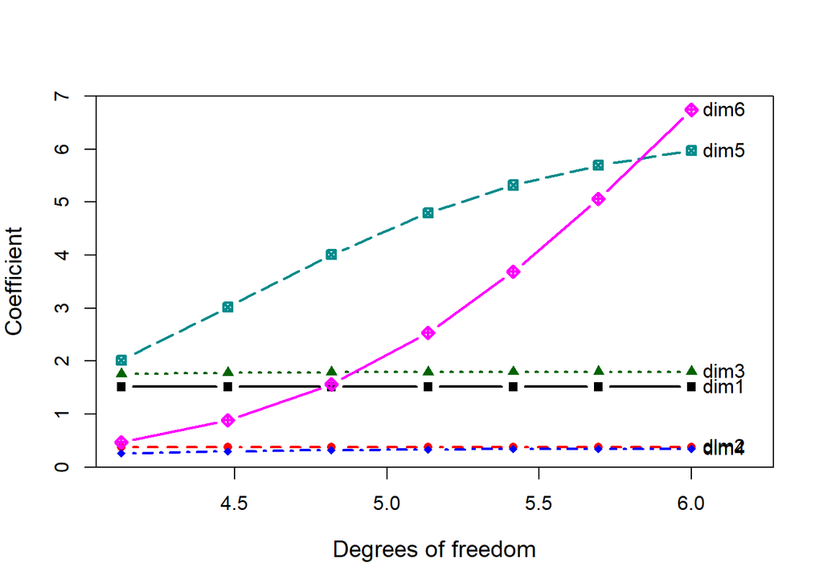

```r
traceplot(plridge, X="df",
          cex.lab = 1.2, lwd=2)
```

## View the last two dimensions

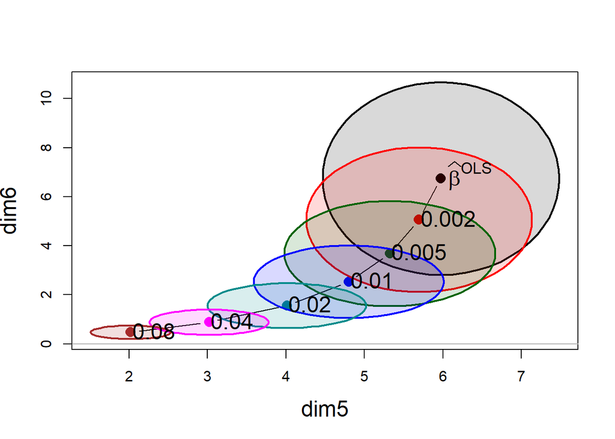

```r
plot(plridge, variables=5:6,
     fill = TRUE, fill.alpha=0.15, cex.lab = 1.5)
text(plridge$coef[, 5:6],
     label = lambdaf,
     cex=1.5, pos=4, offset=.1)
```

## Add variable vectors: `biplot()` method

The `biplot()` method produces a 2D plot of the covariance ellipses for two dimensions in PCA space, defaulting to the last two dimensions where things get interesting. Variable vectors show the projection of the variables into this space, facilitating interpretation.

```r
biplot(plridge, radius=0.5,
       ref=FALSE, asp=1,
       var.cex=1.15, cex.lab=1.3, col=clr,
       fill=TRUE, fill.alpha=0.15,
       prefix="Dimension ")
```

```
## Vector scale factor set to  5.247
```

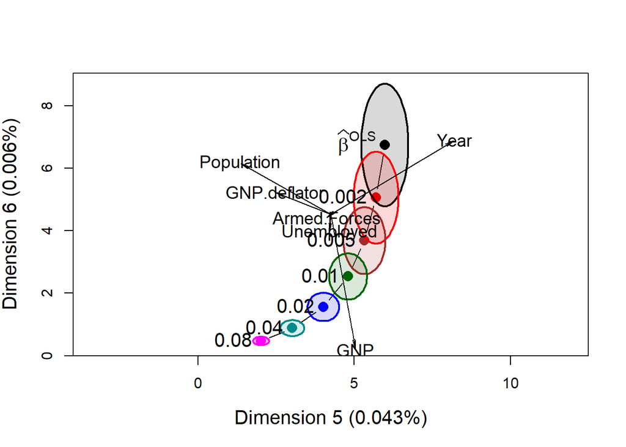

```r
text(plridge$coef[,5:6], lambdaf, pos=2, cex=1.3)
```